# ZWYX: Introduction

James R. Walters

6 July 2022

#### Package

ZWYX 0.0.0.9000

# 1 Overview

The ZWYX package aims to provide a streamlined workflow for identifying sex-linked regions of a genome assembly by comparing sequencing depth between males and females.

## 1.1 Principles: Sex linkage and sequencing coverage

In species with differentiated sex chromosomes, the X or Z chromosomes should show a two-fold difference in sequencing coverage between sexes, while the sex-specific Y or W chromosomes should show an opposing and far more biased pattern of coverage. Autosomes should show no differences.

Using sex-specific sequencing coverage is an established method for identifying scaffolds derived from X, Y, W, or Z chromosomes. ZWYX provides data structures and functions for identifying and visualizing genome scaffolds with sex-biased coverage on average as a whole, but also via windows along each scaffold.

ZWYX also incorporates “changepoint” algorithms for detecting shifts in sex-specific coverage that occur within a scaffold, which typically indicate a mis-assembly that erroneously joins autosomal and sex-linked regions.

## 1.2 Workflow summary

- **Input:** The starting point for ZWYX analysis is a table of read counts in regularly spaced windows across the genome, such as can be generated via [bedtools multicov](https://bedtools.readthedocs.io/en/latest/content/tools/multicov.html).
- **Data Structure:** The table of read counts is combined with sample metadata (e.g. sex) in a `SummarizedExperiment` object.
- **Normalization:** Read counts in each window are normalized for sequencing depth to allow meaningful comparisons between samples.
- **Analysis:** Log2 ratios of read-coverage are calculated between sexes for each scaffold. Based on this statistic, scaffolds (or scaffold segments) are partitioned as being sex-linked or autosomal.
- **Visualization:** Results are plotted, either as individual scaffolds or as windows along scaffolds with detected changepoints.

# 2 Example Data

## 2.1 Test case reference genome

As a test case for demonstrating the usage of ZWYX, we will use a manipulated version of the *Drosophila melanogaster* genome assembly. To approximate a structure typical of a newly *de novo* assembled draft genome, each chromosome arm was divided into log-scaled fragments. The X, 2L, 2R, 3L, and 3R portions were each split into 15 fragments, while the smaller Y and 4 chromosomes were each split into 7 fragments. Then a set of reciprocal translocations between autosomes and sex chromosomes were introduced into the fragmented assembly, as follows.

For the following the pairs of chromosomal fragments:

- X.2 ↔︎ Auto 2L.2
- X.4 ↔︎ Auto 2L.4
- Y.1 ↔︎ Auto 2R.1

Two reciprocal translocations were introduced in each fragment:

| Start (Kbp) | Length (Kbp) |
| --- | --- |
| 150 | 500 |
| 850 | 50 |

Additionally, a different pair of translocations were created for

- Y.3 ↔︎ Auto 2R.13

corresponding to:

| Start (Kbp) | Length (Kbp) |
| --- | --- |
| 100 | 100 |
| 400 | 25 |

This creates a reference genome with 89 scaffolds in it, 8 of which have manually induced sex-chromosome chimeras in them at known positions, which ZWYX can detect and categorize.

## 2.2 Sex-specific Illumina data

To detect sex-specific sequencing coverage with ZWYX, we must first align Illumina sequencing data from male and female samples to the reference assembly. In our example, we will use 3 male and 3 female samples corresponding to “controls” in a [data set generated by Harbison *et al.* (2017).](https://www.ncbi.nlm.nih.gov/bioproject/PRJNA369048) These sequencing data were aligned to the manipulated reference and for each sample reads were counted in 2000 bp windows across the genome.

The resulting read counts per window in each sample can be found in the `dmel_counts` dataframe provided with the ZWYX package.

```r
library(ZWYX)
data("dmel_counts")
head(dmel_counts)
```

```
#>         scaffold start   end SRR5217184 SRR5217228 SRR5217239 SRR5217250 SRR5217251 SRR5217254
#> 1 2L.1_1_5878428     0  2000       2451       2249       2022       1702       2029       1579
#> 2 2L.1_1_5878428  2000  4000       2920       2428       2410       1977       2276       1741
#> 3 2L.1_1_5878428  4000  6000       2341       2025       1803       1641       1827       1441
#> 4 2L.1_1_5878428  6000  8000       1688       1485       1315       1164       1375       1100
#> 5 2L.1_1_5878428  8000 10000       1475       1512       1305       1108       1306       1035
#> 6 2L.1_1_5878428 10000 12000       1743       1553       1472       1332       1438       1154
```

# 3 Example Analysis

## 3.1 Initiating a `SummarizedExperiment` data structure

The `dmel_counts` dataframe is a representative starting point for using ZWYX. Functions in ZWYX generally assume that data are provided in a `SummarizedExperiment` object with rows structured as `GenomicRanges`. So the first step in a ZWYX analysis is to create the properly structured `SummarizedExperiment` object with the required metadata. (Please see the [vignette for `SummarizedExperiment`](https://bioconductor.org/packages/release/bioc/vignettes/SummarizedExperiment/inst/doc/SummarizedExperiment.html) to learn more about this particular data structure)

Creating the needed `SummarizedExperiment` object from the `dmel_counts` dataframe is a three-step process. Before beginning, we will need to load the `SummarizedExperiment` package.

**First**, we will create a `GenomicRanges` object to capture the window coordinates corresponding to read counts.

```r
suppressPackageStartupMessages( library(SummarizedExperiment) )
counts_ranges.dmel <- makeGRangesFromDataFrame(df = dmel_counts, seqnames.field = "scaffold")
counts_ranges.dmel
```

```
#> GRanges object with 68818 ranges and 0 metadata columns:
#>                      seqnames        ranges strand
#>                         <Rle>     <IRanges>  <Rle>
#>       [1]      2L.1_1_5878428        0-2000      *
#>       [2]      2L.1_1_5878428     2000-4000      *
#>       [3]      2L.1_1_5878428     4000-6000      *
#>       [4]      2L.1_1_5878428     6000-8000      *
#>       [5]      2L.1_1_5878428    8000-10000      *
#>       ...                 ...           ...    ...
#>   [68814] Y.7_3431854_3667352 226000-228000      *
#>   [68815] Y.7_3431854_3667352 228000-230000      *
#>   [68816] Y.7_3431854_3667352 230000-232000      *
#>   [68817] Y.7_3431854_3667352 232000-234000      *
#>   [68818] Y.7_3431854_3667352 234000-235499      *
#>   -------
#>   seqinfo: 89 sequences from an unspecified genome; no seqlengths
```

**Second**, we create a dataframe containing the relevant metadata for the samples.

```r
sample.dmel <- data.frame("sampleID" = names(dmel_counts)[-(1:3)],
                          "gamety" = c("Het","Het","Hom","Hom","Het","Hom")
               )
```

**NOTE:** The inclusion of the `gamety` column is *essential* for ZWYX functionality. The `gamety` column should be a character vector, with `"Het"` and `"Hom"` indicating “Heterogametic” and “Homogametic” according to sex chromosome complement of your study species. In *D. melanogaster* , males carry the Y chromosome and are thus heterogametic.

**Third**, we combine these data structures together into a `SummarizedExperiment` object.

```r
count.se <- SummarizedExperiment(assays = list("counts" = dmel_counts[,-(1:3)]),
                                 rowRanges = counts_ranges.dmel,
                                 colData = sample.dmel)
count.se
```

```
#> class: RangedSummarizedExperiment
#> dim: 68818 6
#> metadata(0):
#> assays(1): counts
#> rownames(68818): 1 2 ... 68817 68818
#> rowData names(0):
#> colnames(6): SRR5217184 SRR5217228 ... SRR5217251 SRR5217254
#> colData names(2): sampleID gamety
```

## 3.2 Normalizing data

With the data properly structured in a `SummarizedExperiment` object, we can proceed with further analyses. An important first step is normalizing the data, which in this case just means accounting for overall depth of sequencing in each sample. This is accomplished by dividing each window’s read count by a constant factor for a given sample. One simple option is to divide by the total reads aligned in that sample.

```r
norm.tot <- normalizeCounts(se = count.se, method = "totalreads")
norm.tot
```

```
#> class: RangedSummarizedExperiment
#> dim: 68818 6
#> metadata(0):
#> assays(2): counts normdata
#> rownames(68818): 1 2 ... 68817 68818
#> rowData names(0):
#> colnames(6): SRR5217184 SRR5217228 ... SRR5217251 SRR5217254
#> colData names(5): sampleID gamety totalReads windowmedian NormMethod
```

This creates a second entry in `assays` corresponding to the normalized (and rescaled) values. These normalized values will be used by subsequent ZWYX functions for comparisons between sexes.

```r
head(assays(norm.tot)[["normdata"]])
```

```
#>   SRR5217184 SRR5217228 SRR5217239 SRR5217250 SRR5217251 SRR5217254
#> 1   2608.522   2458.111   2400.220   2232.170   2546.062   2287.752
#> 2   3107.664   2653.754   2860.796   2592.832   2856.006   2522.467
#> 3   2491.453   2213.284   2140.255   2152.169   2292.585   2087.809
#> 4   1796.485   1623.075   1560.974   1526.584   1725.399   1593.747
#> 5   1569.796   1652.585   1549.103   1453.140   1638.816   1499.571
#> 6   1855.020   1697.397   1747.341   1746.916   1804.454   1671.986
```

ZWYX also provides an alternative option to normalize by median depth across windows, if desired.

## 3.3 Assaying sex linkage by ratios

We can now use the normalized read counts to calculate coverage ratios for each scaffold. A ratio of mean values in each sex are reported as Log2(Heterogametic:Homogametic). Single representative values for each scaffold are based on sums across windows in each scaffold.

Scaffolds are assigned to be “Autosomal”, “X|Z”, or “Y|W” depending on specific thresholds applied the Log2(Heterogametic:Homogametic). By default, the threshold is set at 0.5 and -0.5, respectively, but can be modified in the `getRatiosByScaff()` function.

```r
scaffoldRatiosTot <- getRatiosByScaff(norm.tot)
head(scaffoldRatiosTot)
```

```
#>                                                          scaffold  log2homhet Linkage scaffLen
#> 2L.1_1_5878428                                     2L.1_1_5878428 -0.04779397    Auto  5878428
#> 2L.2_5878429_9317088_chimeraAX     2L.2_5878429_9317088_chimeraAX  0.05582201    Auto  3438660
#> 2L.3_9317089_11756856                       2L.3_9317089_11756856 -0.05348535    Auto  2439768
#> 2L.4_11756857_13649288_chimeraAX 2L.4_11756857_13649288_chimeraAX  0.13739354    Auto  1892432
#> 2L.5_13649289_15195516                     2L.5_13649289_15195516 -0.07533714    Auto  1546228
#> 2L.6_15195517_16502834                     2L.6_15195517_16502834 -0.11220714    Auto  1307318
```

The resulting dataframe can be used directly for visualizing coverage ratios and assigned linkage.

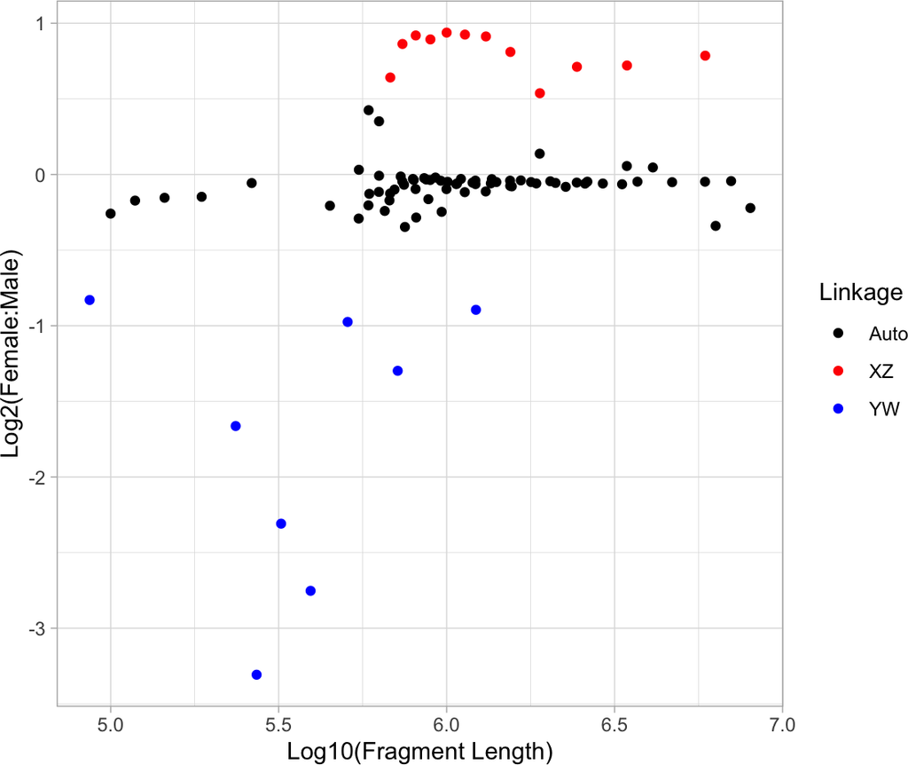

```r
library(ggplot2)
ggplot(data = scaffoldRatiosTot, aes(x=log10(scaffLen), y = log2homhet, col = Linkage)) + geom_point() +
          labs(y = "Log2(Female:Male)", x = "Log10(Fragment Length)") +
   scale_color_manual(values = c("black","red", "blue")) + theme_light()
```

In this case, since the reference assembly was engineered, we can check these linkage assignments against what the true chromosomal linkage is, and whether a chromosome fragment (e.g. “scaffold”) carried a translocation and thus was *chimeric*.

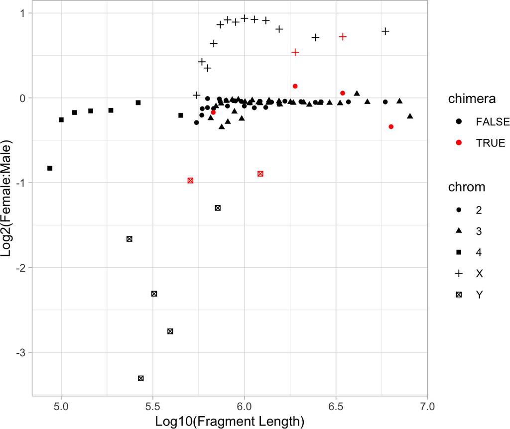

```r
scaffoldRatiosTot$chimera <- grepl(x = scaffoldRatiosTot$scaffold, pattern="chimera")
scaffoldRatiosTot$chrom <- gsub(x=scaffoldRatiosTot$scaffold,
                                pattern = "(\\w)\\w?\\..*", rep="\\1", perl = T)

ggtot <- ggplot(data = scaffoldRatiosTot, aes(x=log10(scaffLen), y = log2homhet,
               col = chimera, pch = chrom)) + geom_point() +
               scale_color_manual(values = c("black","red"))  +
               labs(y = "Log2(Female:Male)", x = "Log10(Fragment Length)") +
               theme_light()
print(ggtot)
```

# 4 Changepoint analysis

This analysis that assigns whole scaffolds as being autosome or sex-linked rests on the assumption that the assembly is correct. However, assembly errors may commonly occur that result in scaffolds which erroneously join sex-linked and autosomal regions of the genome. Such chimeric scaffolds should produce sharp changes in sex-specific sequencing coverage along the scaffold, which can be detected by “changepoint” algorithms.

ZWYX applies algorithms from [the `changepoint` package](https://CRAN.R-project.org/package=changepoint) to detect shifts in sequencing coverage ratios along single scaffold using read counts from each window. As above with analyses of whole scaffolds, segments with mean values above or below specific thresholds are assigned to be sex-linked.

The `runChangepointOnSE` function analyzes all scaffolds present in the provided `SummarizedExperiment` object and returns results for each scaffold in a list.

```r
cp.out <- runChangepointOnSE(se = norm.tot)
```

For each scaffold it returns a list of length 4, comprised of:

1. `$InputGR` A GenomicRanges representation of log2(ratio) data input to the changepoint algorithm
2. `$SegmentsGR` A GenomicRanges represntation of the segments detected by changepoint analysis
3. `$Changepoint` The `changepoint` object output directly from the `cpt.mean()` function
4. `$FilteredWindows` A vector of indices corresponding to windows in `$InputGR`(1) which had `Inf` coverage ratios and thus (if any) were excluded from the Changepoint analysis.

Here is an example of an autosomal fragment engineered to contain two X-linked segments

```r
cp.out[["2L.2_5878429_9317088_chimeraAX"]]
```

```
#> $InputGR
#> GRanges object with 1720 ranges and 7 metadata columns:
#>                      seqnames          ranges strand | SRR5217184 SRR5217228 SRR5217239 SRR5217250
#>                         <Rle>       <IRanges>  <Rle> |  <numeric>  <numeric>  <numeric>  <numeric>
#>   2941 2L.2_5878429_9317088..          0-2000      * |    1380.36    1506.13    1324.75    1429.53
#>   2942 2L.2_5878429_9317088..       2000-4000      * |    1575.12    1606.68    1436.33    1463.63
#>   2943 2L.2_5878429_9317088..       4000-6000      * |    1713.47    1720.35    1761.59    1613.14
#>   2944 2L.2_5878429_9317088..       6000-8000      * |    1637.91    1459.13    1679.68    1513.47
#>   2945 2L.2_5878429_9317088..      8000-10000      * |    1492.10    1453.66    1481.44    1342.97
#>    ...                    ...             ...    ... .        ...        ...        ...        ...
#>   4656 2L.2_5878429_9317088.. 3430000-3432000      * |   1484.655   1695.211   1517.053   1455.763
#>   4657 2L.2_5878429_9317088.. 3432000-3434000      * |   1356.943   1389.177   1372.233   1388.877
#>   4658 2L.2_5878429_9317088.. 3434000-3436000      * |   1545.318   1454.756   1559.787   1395.434
#>   4659 2L.2_5878429_9317088.. 3436000-3438000      * |   1623.010   1552.031   1467.197   1314.121
#>   4660 2L.2_5878429_9317088.. 3438000-3438660      * |    433.157    437.192    396.475    400.007
#>        SRR5217251 SRR5217254 log2homhet
#>         <numeric>  <numeric>  <numeric>
#>   2941    1374.05    1317.01 -0.0655431
#>   2942    1486.98    1372.07 -0.1281209
#>   2943    1711.60    1658.95 -0.0316764
#>   2944    1651.36    1498.12 -0.0174631
#>   2945    1333.89    1303.98 -0.0519160
#>    ...        ...        ...        ...
#>   4656   1459.374   1408.293 -0.0825924
#>   4657   1292.481   1344.543  0.0237560
#>   4658   1476.942   1485.083 -0.0118790
#>   4659   1665.167   1402.498 -0.2102497
#>   4660    406.567    452.045 -0.0324364
#>   -------
#>   seqinfo: 89 sequences from an unspecified genome; no seqlengths
#>
#> $SegmentsGR
#> GRanges object with 5 ranges and 2 metadata columns:
#>                     seqnames         ranges strand | MeanLog2HetHom     Linkage
#>                        <Rle>      <IRanges>  <Rle> |      <numeric> <character>
#>   [1] 2L.2_5878429_9317088..       1-147999      * |     0.00042721        Auto
#>   [2] 2L.2_5878429_9317088..  148000-647999      * |     0.89064680          XZ
#>   [3] 2L.2_5878429_9317088..  648000-847999      * |    -0.03025641        Auto
#>   [4] 2L.2_5878429_9317088..  848000-897999      * |     1.00207569          XZ
#>   [5] 2L.2_5878429_9317088.. 898000-3438660      * |    -0.05679425        Auto
```

[output cut: 8 more lines]

```
#> Created on  : Tue Mar 22 14:16:26 2022
#>
#> summary(.)  :
#> ----------
#> Created Using changepoint version 2.2.3
#> Changepoint type      : Change in mean
#> Method of analysis    : PELT
#> Test Statistic  : Normal
#> Type of penalty       : Hannan-Quinn with value, 8.032899
#> Minimum Segment Length : 5
#> Maximum no. of cpts   : Inf
#> Changepoint Locations : 75 325 425 450
#>
#> $FilteredWindows
#> named integer(0)
```

While this output comprehensively captures the analysis, it is also cumbersome. Furthermore, adjacent segments may be detected which share the same linkage assignments. (For instance, adjacent segments with Log2(Het:Hom) of -1.3 and -1.7, respectively, will both be considered Y-like). So it is often desirable to distill these results into a single summary object with `mergeSegment()`, which produce either a dataframe or GRangesList object.

Here is an example for the dataframe output. Note that the Log2(Het:Hom) statistic is removed from this output, since that statistic is determined by segment. With segments being merged, this statistic is dropped.

```r
outsegs.df <- mergeSegments(changeList = cp.out[1:3], asDF = TRUE)
head(outsegs.df)
```

```
#>   group                     group_name                       seqnames  start     end   width
#> 1     1                 2L.1_1_5878428                 2L.1_1_5878428      1 5878428 5878428
#> 2     2 2L.2_5878429_9317088_chimeraAX 2L.2_5878429_9317088_chimeraAX      1  147999  147999
#> 3     2 2L.2_5878429_9317088_chimeraAX 2L.2_5878429_9317088_chimeraAX 148000  647999  500000
#> 4     2 2L.2_5878429_9317088_chimeraAX 2L.2_5878429_9317088_chimeraAX 648000  847999  200000
#> 5     2 2L.2_5878429_9317088_chimeraAX 2L.2_5878429_9317088_chimeraAX 848000  897999   50000
#> 6     2 2L.2_5878429_9317088_chimeraAX 2L.2_5878429_9317088_chimeraAX 898000 3438660 2540661
#>   strand Linkage
#> 1      *    Auto
#> 2      *    Auto
#> 3      *      XZ
#> 4      *    Auto
#> 5      *      XZ
#> 6      *    Auto
```

# 5 Visualizing Segments

The results of `runChangepointOnSE()` can be visualized for each scaffold using the `zwyxPlot()` function.

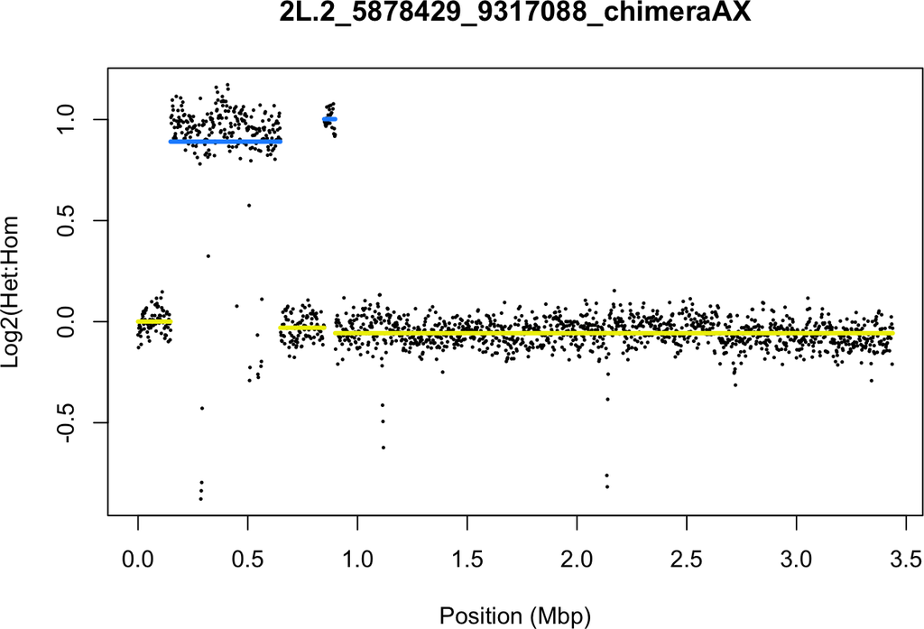

```r
# Extract a known chimeric scaffold for demonstration
cp <- cp.out[[2]]
zwyxPlot(InputGR = cp[[1]], SegmentGR = cp[[2]], bpunit = "mbp",
         pch = 19, cex = 0.2, seglwd = 3, main = unique(seqnames(cp[[1]])) ,
         xlab = "Position (Mbp)", ylab = "Log2(Het:Hom")
```

The function uses the GenomicRanges object of Log2(Het:Hom) ratios, and also of the detected changepoint segments, which are the first two elements that are produced by the function `runChangepointOnSE()`.

In our example data, we can look at all of the engineered “chimeric” scaffolds using `zwyxPlot()`.

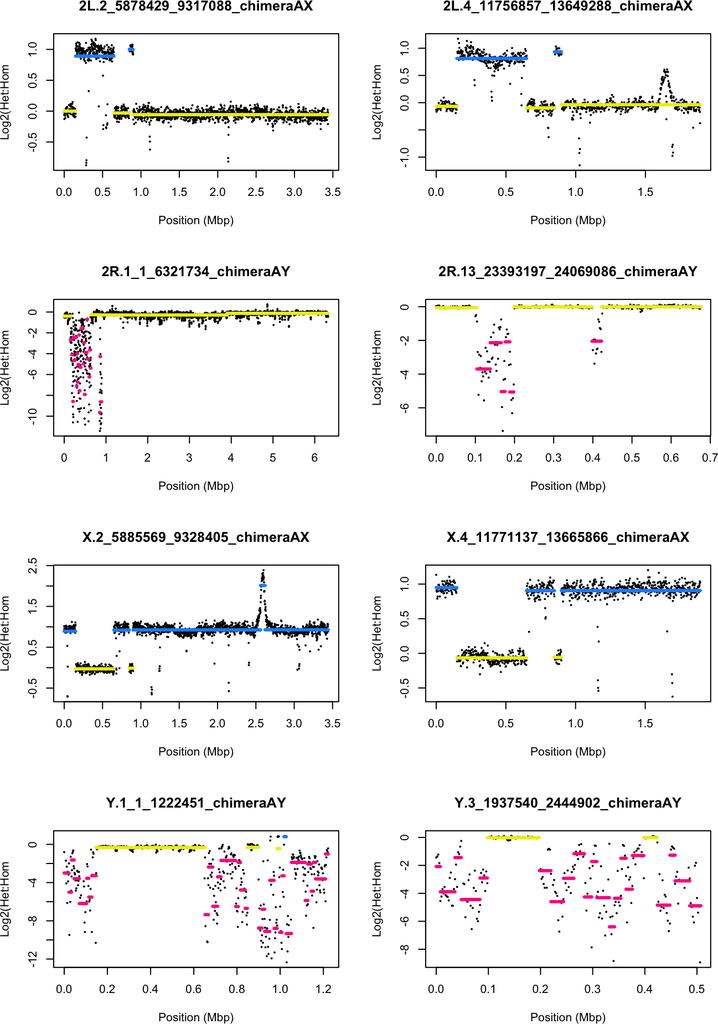

```r
chimera.ind <- which(scaffoldRatiosTot$chimera)


par(mfrow = c(4,2))
for (nscaff in chimera.ind) {
   zwyxPlot(InputGR = cp.out[[nscaff]][[1]], SegmentGR = cp.out[[nscaff]][[2]],
            bpunit="mbp", pch = 19, cex = .2, seglwd = 3,
            main = names(cp.out [nscaff]),  xlab = "Position (Mbp)", ylab = "Log2(Het:Hom" )
}
```